# 🕶 Interesting ‘facts’ I found

Author: Youngbin Kim

```r
library(mosaic)
library(ggplot2)
```

Here is a visualization of top 10 words that are used in fake news and true news. Then I combined them to see the what words are commonly used in both fake news and true news.

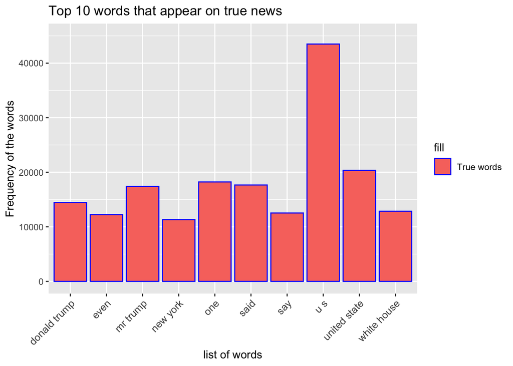

```r
true.data = read.csv("~/Downloads/trueData.csv")
fake.data = read.csv("~/Downloads/fakeData.csv")

fake.word.10 = c(fake.data$word[1:10])
fake.freq.10 = c(fake.data$freq[1:10])
fake.rank.10 = c(fake.data$rank[1:10])
fake.data.10 = data.frame(fake.word.10,fake.freq.10,fake.rank.10)

true.word.10 = c(true.data$word[1:10])
true.freq.10 = c(true.data$freq[1:10])
true.rank.10 = c(true.data$rank[1:10])
true.data.10 = data.frame(true.word.10,true.freq.10,true.rank.10)

#True Graph
ggplot(true.data.10, aes(x = true.word.10, y = true.freq.10, fill = "True words")) + geom_bar(stat = "identity", col = " blue") + ylim(0,45000) + ggtitle("Top 10 words that appear on true news") + xlab("list of words") + ylab("Frequency of the words") + theme(axis.text.x = element_text(size = 10, angle = 45, hjust = 1))
```

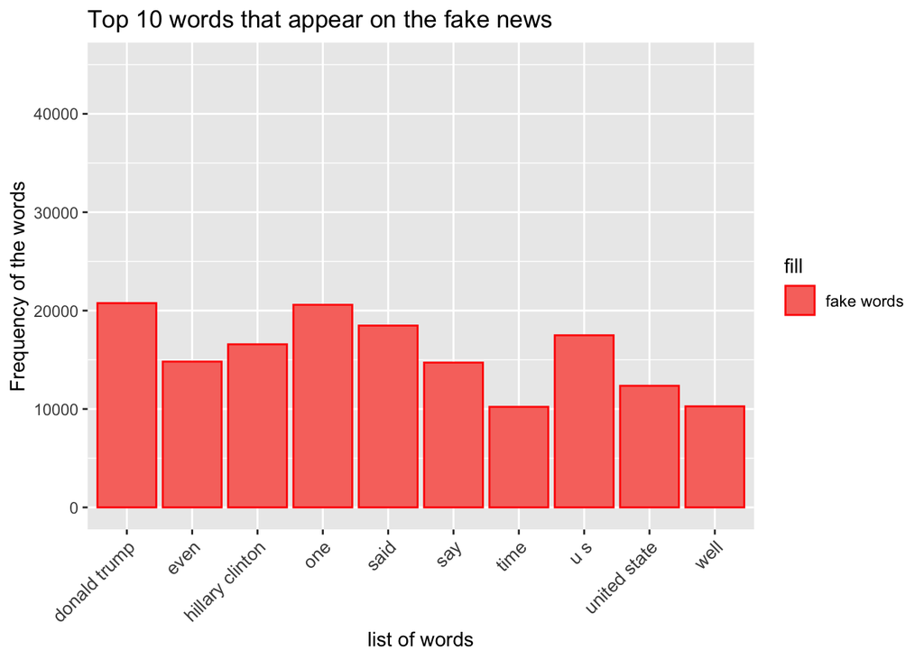

```r
#Fake graph
ggplot(fake.data.10, aes(x = fake.word.10, y = fake.freq.10, fill = "fake words")) + geom_bar(stat = "identity", col = " red") + ylim(0,45000) + ggtitle("Top 10 words that appear on the fake news") + xlab("list of words") + ylab("Frequency of the words") + theme(axis.text.x = element_text(size = 10, angle = 45, hjust = 1))
```

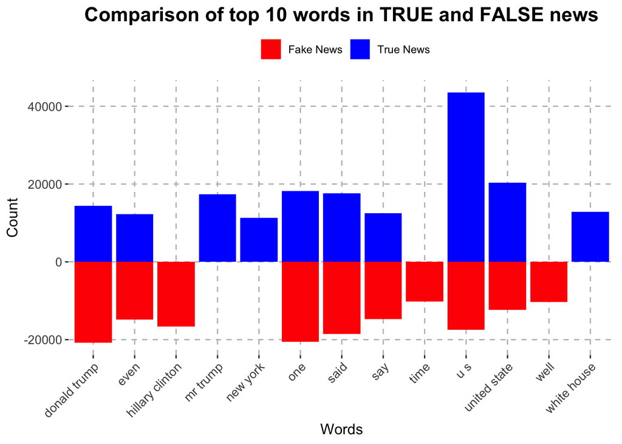

```r
#combining two graphs for the visualization
compare_plot <- ggplot() +
  geom_bar(data=true.data.10, aes(x=true.word.10, y=true.freq.10, fill="True News"), position="dodge", stat="identity") +
  geom_bar(data=fake.data.10, aes(x=fake.word.10, y=-fake.freq.10, fill="Fake News"), position="dodge", stat="identity") +
  scale_fill_manual(values=c("True News"="blue", "Fake News"="red")) +
  ggtitle("Comparison of top 10 words in TRUE and FALSE news") +
  xlab("Words") +
  ylab("Count") +
  theme(legend.title=element_blank(),
        axis.text.x = element_text(size = 10, angle = 45, hjust = 1),
        axis.text.y = element_text(size = 10),
        axis.title.x = element_text(size = 12),
        axis.title.y = element_text(size = 12),
        plot.title = element_text(size = 16, face = "bold", hjust = 0.5),
        panel.background = element_rect(fill = "white"),
        panel.grid.major = element_line(colour = "gray", linetype = "dashed"),
        panel.grid.minor = element_blank(),
        panel.border = element_blank(),
        legend.position = "top")

compare_plot
```

The word “fact” is used in both fake news and true news. However, I was pretty surprised that the word fact has been used more in fake news rather than true news. Thus, I am going to find out how much the word “fact” is used in fake news compare to the true news using ratio estimation. By conducting ratio estimation, I can determine whether the word “fact” appears more frequently in fake news or true news, and by how much if it appears more frequently. Since I will be using fake news as a reference variable for this estimation, if the result is less than 1, it will indicate that the word “fact” is used more frequently in true news. If the result is greater than 1, it will indicate that the word “fact” is used more frequently in fake news.

```r
true.data = read.csv("~/Downloads/trueData.csv")
fake.data = read.csv("~/Downloads/fakeData.csv")

#extracting the top 150 words from the fake news data file.
fake.word.150 = c(fake.data$word[1:150])
fake.freq.150 = c(fake.data$freq[1:150])
fake.rank.150 = c(fake.data$rank[1:150])
fake.article.150 = c(fake.data$article_count[1:150])
fake.data.150 = data.frame(fake.word.150,fake.freq.150,fake.rank.150,fake.article.150)

#extracting the top 150 words from the true news data file.
true.word.150 = c(true.data$word[1:150])
true.freq.150 = c(true.data$freq[1:150])
true.rank.150 = c(true.data$rank[1:150])
true.article.150 = c(true.data$article_count[1:150])
true.data.150 = data.frame(true.word.150,true.freq.150,true.rank.150,true.article.150)

#combining extracted data file together
combine.df = data.frame(true.data.150,fake.data.150)


#finding the article count in fake news using the word "fact"
if("fact" %in% fake.data.150$fake.word.150) {
  article.fake = fake.data.150$fake.article.150[fake.data.150$fake.word.150 == "fact"]
  print(article.fake)
} else {
  print("The word fact is not in the word list")
}
```

```
## [1] 10271
```

```r
#finding the article count in true news using the word "fact"
if("fact" %in% true.data.150$true.word.150) {
  article.true = true.data.150$true.article.150[true.data.150$true.word.150 == "fact"]
  print(article.true)
} else {
  print("The word fact is not in the word list")
}
```

```
## [1] 6262
```

```r
#I will use ration estimation for the proportion.
#I am going to find the proportion of the word "fact" usage in fake news and true news

#The large N represent the total population which is the number of article that appears on fake news and true news
N.article = sum(fake.data.150$fake.article.150) + sum(true.data.150$true.article.150)
N.article
```

```
## [1] 2677380
```

```r
#The small n represent the sample population which this case would be the number of article count with the word fact
n.article = sum(article.true,article.fake)
n.article
```

```
## [1] 16533
```

```r
#now finding the ration. I am going to call it rhat.
#since I have fake.article on the numerator, the confidence interval is based on article fake.
rhat = article.fake/article.true
rhat
```

```
## [1] 1.640211
```

```r
#variance will be used to calculate my margin of error
dev.article = fake.data.150$fake.article.150 - (rhat * fake.data.150$fake.article.150)
var.article = var(dev.article)
var.article
```

```
## [1] 14916831
```

```r
#moe = margin of error, and  want it to be 95% confident
confidence = 1-((1-0.95)/2)
confidence
```

```
## [1] 0.975
```

```r
moe = qnorm(confidence) * sqrt((1/article.true^2) * ((N.article - n.article)/N.article) * (var.article / n.article))
moe
```

```
## [1] 0.009372435
```

```r
lower.bound = rhat - moe
upper.bound = rhat + moe
lower.bound
```

```
## [1] 1.630838
```

```r
upper.bound
```

```
## [1] 1.649583
```

$1.630838 \leq \mu\leq 1.649583$ : Therefore, I can conclude that I am 95% confident that the proportion of word usage “fact” in fake news is somewhere between 1.630838 to 1.649583 higher compared to the true news.

Now, let’s take a look at the visualization.

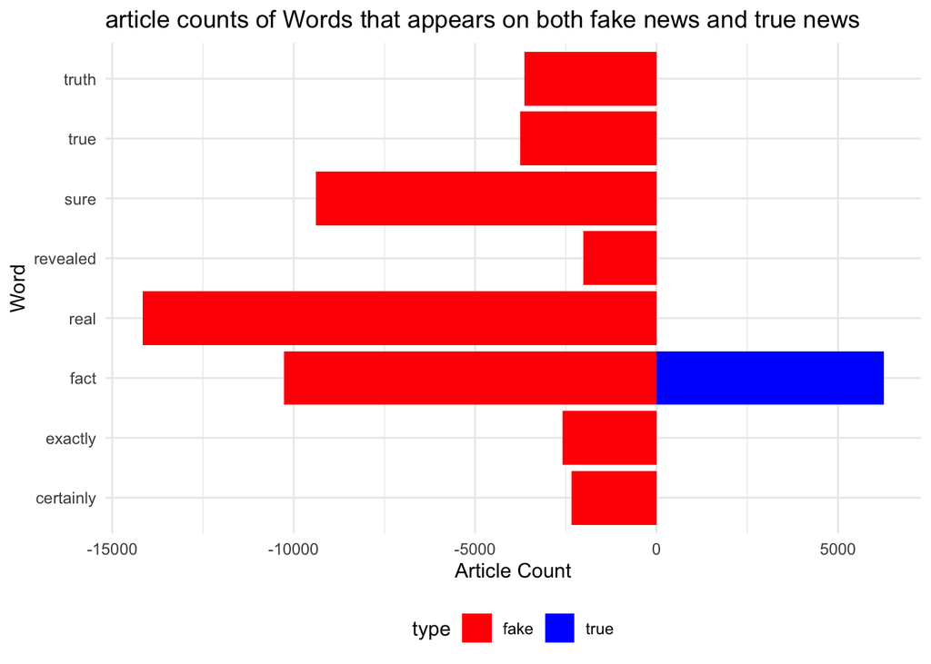

```r
library(dplyr)
library(ggplot2)

# list of words that will be used for analysis. The words are related to the certainty, belief, trust.
my.words <- c("fact", "true", "real", "truth", "revealed", "certainly", "exactly", "sure")

# extract the words in each file
new.data.fake <- fake.data %>%
  filter(word %in% my.words) %>%
  select(word, article_count) %>%
  mutate(type = "fake")

new.data.true <- true.data %>%
  filter(word %in% my.words) %>%
  select(word, article_count) %>%
  mutate(type = "true")

#combining two data
merged_data <- bind_rows(new.data.fake, new.data.true)

# Visualization
library(ggplot2)

ggplot(data = merged_data, aes(x = ifelse(type == "fake", -article_count, article_count), y = word, fill=type)) +
  geom_bar(stat="identity", position="identity") +
  xlab("Article Count") +
  ylab("Word") +
  ggtitle("article counts of Words that appears on both fake news and true news") +
  theme_minimal() +
  scale_fill_manual(values=c("red", "blue")) +
  theme(legend.position="bottom")
```

As shown in the visual, the word “fact” is more frequently used in fake news. Other specific words such as “real”, “true”, “truth”, and “revealed” are also more commonly used in fake news than in real news. Additionally, words that express trust and certainty, such as “certainly”, “exactly”, and “sure”, are more frequently used in fake news. It is ironic that real news, which is intended to convey accurate information, tends to use fewer words related to truth, trust, and certainty, while fake news uses them more frequently. Therefore, when someone tries to persuade us with strong conviction and trust, it may be wise to approach the situation with a healthy dose of skepticism.